# Anomalías térmicas en el Parque Nacional Palo Verde — VIIRS

Detecciones del sensor VIIRS (VIIRS_SNPP_SP de NASA FIRMS) y área quemada (VNP64A1)

Autor/a

Organización Incendios Forestales

Fecha de publicación

21 de octubre de 2026

## Introducción

Este reporte presenta las anomalías térmicas (detecciones de fuego activo) registradas por el sensor **VIIRS** a bordo del satélite Suomi-NPP en el [Parque Nacional Palo Verde](https://www.sinac.go.cr/), Costa Rica. Es el análogo del reporte basado en MODIS, con la misma metodología y los mismos productos, pero con un instrumento distinto: los datos provienen del producto **VIIRS_SNPP_SP** (procesamiento estándar) del sistema [FIRMS](https://firms.modaps.eosdis.nasa.gov/) de la NASA y el área quemada del producto **VNP64A1**. Existe además un tercer reporte con el VIIRS de NOAA-20, el mismo instrumento en otra plataforma, con registro desde 2018.

Las dos series se publican por separado y **no deben sumarse ni empalmarse**: VIIRS observa con un píxel de 375 m frente al de ~1 km de MODIS, de modo que detecta muchos más fuegos —y fuegos más pequeños— sobre el mismo territorio. Cualquier serie que uniera ambos sensores mostraría un salto artificial en 2012, cuando VIIRS entra en operación, que sería un cambio de instrumento y no un cambio en el régimen de fuego.

El interés de VIIRS es doble. Por un lado es la **continuidad** del registro: las misiones Terra y Aqua, que llevan MODIS, terminan en 2027. Por otro, su mayor resolución permite contrastar los hallazgos obtenidos con MODIS y distinguir cuáles son propiedades del fuego y cuáles artefactos del tamaño del píxel.

El período analizado va del **25/02/2012** al **31/05/2026**, con un total de **296** detecciones dentro del parque. El límite del parque proviene de la capa oficial de áreas silvestres protegidas del SINAC (escala 1:5000, publicada en 2019): está delimitado con una precisión muy superior a la de los píxeles VIIRS (375 m en el nadir), así que el recorte no introduce error apreciable por la geometría del límite.

## Mapa animado

Detecciones mensuales de anomalías térmicas; el color indica la potencia radiativa del fuego (FRP).

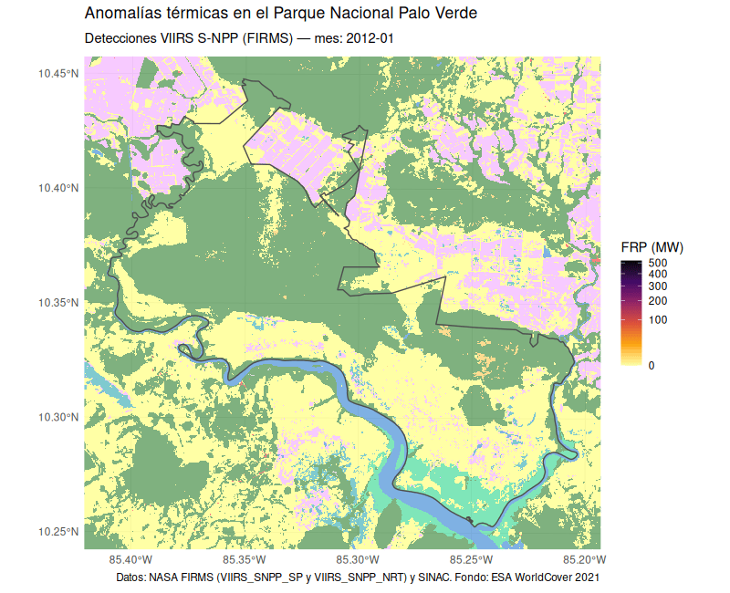

## Video resumen

Resumen mensual en formato de video: detecciones de fuego activo (VIIRS) con su estela de los meses recientes y píxeles de área quemada (VNP64A1), sobre el relieve del parque teñido por la cobertura de la tierra (WorldCover 2021). Los contadores muestran el acumulado desde el inicio del registro y, debajo, el mes en curso con sus valores, cada serie por separado: son magnitudes complementarias y no sumables.

[video not shown]

El cartel estático resume las dos series mensuales del video: los acumulados arriba y, en paneles separados, las hectáreas quemadas y las detecciones por mes, con el mes máximo de cada serie rotulado.

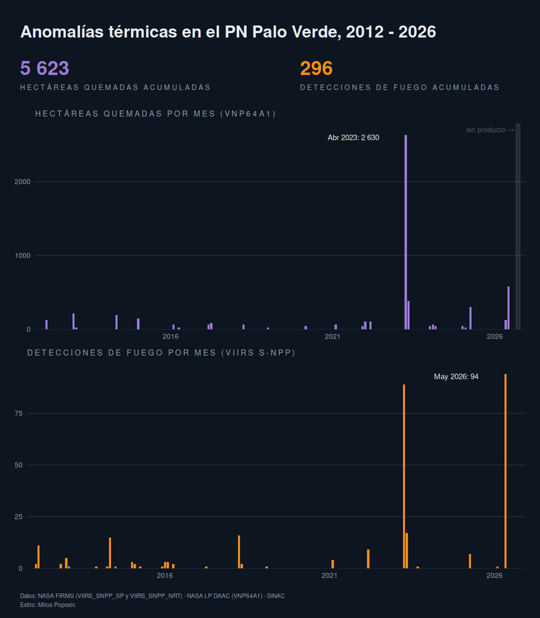

## Mapa interactivo

Use el deslizador temporal para explorar las detecciones a través del tiempo; cada punto muestra sus atributos al pulsarlo, incluida la cobertura de la tierra dominante en su footprint. El botón ⛶ de la esquina superior izquierda abre el mapa en pantalla completa.

A diferencia de MODIS, que reporta la confianza de cada detección como un porcentaje, VIIRS la entrega en tres categorías —baja, nominal y alta—, y así aparece en los popups.

Desde el control de capas pueden apagarse las capas de detecciones y del límite del parque —útil para examinar el fondo— y activarse el área quemada (píxeles de VNP64A1, con su fecha de quema en el popup), que el deslizador filtra igual que las detecciones, la cobertura ([ESA WorldCover 2021](https://esa-worldcover.org/)) y las capas nacionales del SINAC: el Registro Nacional de Humedales y la cobertura forestal 2023.

[interactive chart not shown]

## Área quemada (VNP64A1)

Las detecciones de fuego activo indican dónde había fuego al paso del satélite; el producto complementario **VNP64A1** mapea el **área quemada**: para cada píxel de 500 m (~21,5 ha) registra el día en que la superficie quedó marcada por el fuego, a partir del cambio persistente de reflectancia. Es el heredero directo de MCD64A1 —mismo algoritmo, misma rejilla sinusoidal y misma resolución— aplicado a las bandas de VIIRS, y su registro comienza en marzo de 2012. Igual que con MODIS, FIRMS lista un producto de área quemada (`BA_VIIRS`) pero su API no lo entrega como datos, así que el pipeline lo descarga del archivo original de la NASA (LP DAAC). El producto se publica con uno o dos meses de rezago: su serie puede terminar antes que la de detecciones.

Conviene notar una asimetría: mientras que en fuego activo VIIRS aventaja claramente a MODIS por su píxel de 375 m, en área quemada **ambos productos comparten la resolución de 500 m**. Las diferencias entre MCD64A1 y VNP64A1 no vienen del tamaño del píxel sino de la sensibilidad de las bandas y del comportamiento del algoritmo.

**Limitación**: la unidad mínima de VNP64A1 es el píxel de 500 m —quemas menores pueden no detectarse y la superficie reportada es la del píxel completo, no la de la cicatriz interna—, por lo que las hectáreas son una estimación gruesa, útil para comparar años y estaciones entre sí.

## Estadísticas

### Serie temporal mensual

Detecciones de fuego activo (arriba) y hectáreas quemadas (abajo), con el eje temporal compartido: acerque con la rueda o arrastre una región para explorar un período; pase el cursor sobre una barra para ver el detalle del mes.

Las dos series son complementarias y **no sumables**: las detecciones cuentan eventos de fuego activo en el momento del sobrevuelo —un mismo incendio genera muchas detecciones a lo largo de días—, mientras que el área quemada mide la superficie que quedó marcada, contada una sola vez.

[interactive chart not shown]

### Climatología mensual (estacionalidad)

Promedios por mes calendario de ambas magnitudes. El promedio de hectáreas de los meses más recientes puede estar levemente subestimado por el rezago de publicación de VNP64A1.

[interactive chart not shown]

### Resumen anual

Los años sin detecciones muestran el FRP en blanco (no hubo detecciones que promediar); 0 hectáreas significa que VNP64A1 no marcó píxeles quemados ese año.

| Año | Detecciones | Hectáreas quemadas | FRP promedio (MW) | FRP máximo (MW) |
| --- | --- | --- | --- | --- |
| 2012 | 15 | 128 | 5.1 | 9.86 |
| 2013 | 7 | 235 | 9.7 | 17.91 |
| 2014 | 17 | 192 | 9 | 27.18 |
| 2015 | 7 | 150 | 4.1 | 9.78 |
| 2016 | 8 | 86 | 5.3 | 7.88 |
| 2017 | 1 | 150 | 11 | 11.02 |
| 2018 | 18 | 64 | 5.8 | 12.4 |
| 2019 | 1 | 21 | 7.8 | 7.75 |
| 2020 | 0 | 43 |  |  |
| 2021 | 4 | 107 | 3.9 | 7.22 |

[output cut: 5 more lines]

Un dato llama la atención en la tabla: **2024 no registra ninguna detección** pese a que VNP64A1 sí marca superficie quemada ese año. No es que no hubiera fuego —el reporte MODIS sí registra detecciones en 2024—, sino un hueco del producto de fuego activo de Suomi-NPP, un satélite que ya excede su vida útil de diseño. Es un recordatorio de que la continuidad del registro conviene apoyarla en más de una plataforma.

## Cobertura de la tierra

Cada detección VIIRS corresponde a un píxel de 375 m en el nadir (mayor fuera de él), por lo que la cobertura se caracteriza sobre el *footprint* completo de la detección (una elipse con las dimensiones reales del píxel, columnas `scan` × `track`) y no sobre el punto exacto. El footprint mediano de este registro ronda 0,2 km², frente a más de 1 km² en MODIS: la atribución de cobertura es sustancialmente más precisa, y este es el punto donde más se notará la diferencia entre ambos sensores.

**Limitación**: WorldCover describe la cobertura de 2021, mientras que el registro de detecciones abarca 2012–2026; los cambios de cobertura en ese período no están representados.

Cada barra se divide además según la detección caiga o no dentro de un humedal del [Registro Nacional de Humedales](https://geos1pne.sirefor.go.cr/wfs) del SINAC (actualización 2016–2018 del Inventario Nacional de Humedales). El humedal no es un tipo de vegetación que compita con *pastizal* o *bosque*, sino una condición del sitio: las capas del SINAC inventarían rasgos específicos y no cubren todo el territorio, por lo que no pueden sustituir a WorldCover como clasificación exhaustiva, pero sí complementarla.

[interactive chart not shown]

El gráfico gemelo muestra las **hectáreas quemadas** según la clase dominante del píxel VNP64A1. Aquí la clase se asigna al píxel de 500 m completo —no a un footprint elíptico— y aplica la misma limitación de la foto fija de 2021.

[interactive chart not shown]

### Contraste con el Registro Nacional de Humedales

La clase más frecuente, *pastizal*, merece una advertencia: WorldCover es un producto global y clasifica como pastizal buena parte de la marisma del parque.

| Clase WorldCover | Detecciones | En humedal | % en humedal | Fracción del footprint en humedal | Hectáreas quemadas | % del área quemada en humedal |
| --- | --- | --- | --- | --- | --- | --- |
| Pastizal | 236 | 221 | 93.6 | 0.846 | 3977 | 95.7 |
| Bosque | 52 | 25 | 48.1 | 0.13 | 1026 | 27.1 |
| Manglar | 4 | 4 | 100 | 0.315 | 192 | 100 |
| Cultivos | 3 | 1 | 33.3 | 0.333 | 428 | 25 |
| Humedal herbáceo | 1 | 1 | 100 | 1 | 0 |  |

El resultado es el mismo que con MODIS: el **93,6 %** de las 236 detecciones cuyo footprint domina el *pastizal* de WorldCover caen dentro de un humedal registrado, y en promedio el **85 %** del footprint está cubierto por humedal. Esas quemas no ocurren en potreros sino en el complejo de humedales del parque, y ahora el resultado se sostiene con footprints cinco veces más pequeños, lo que descarta que fuera un efecto de la superposición gruesa del píxel MODIS.

**Advertencia sobre la clase de humedal**: el registro asigna una sola clase por polígono, y el polígono *Sector Catalina 1* (4 453 ha, clasificado como *Manglar*) cubre casi todo el sector estuarino del parque, por lo que concentra 205 detecciones. Eso **no** significa que esas quemas ocurran en manglar. Dentro de ese polígono, el manglar cubre apenas el 11,6 % de la superficie según WorldCover —el 74 % es pastizal— y solo el 4,1 % según la propia capa de Cobertura Forestal 2023 del SINAC, que sí mapea el manglar como una de sus clases.

Es decir, `clase_hum` describe el tipo de humedal *como sitio* —un complejo estuarino cuyo rasgo distintivo es el manglar— y no la cobertura en cada punto de su extensión.

## El episodio del humedal Catalina, mayo de 2026

Casi todo lo que este reporte mide carece de contraparte en tierra: nadie levantó un inventario de las quemas de 2014 para comparar. El episodio de mayo de 2026 es la excepción, y por eso merece una sección propia. El 28 de mayo de 2026 la caída de un rayo encendió el interior del humedal Catalina, y una semana después Delfino.cr reportaba, con cifras del Minae-Sinac, que el fuego había afectado **cerca de 4 000 hectáreas** ([nota del 3 de junio de 2026](https://delfino.cr/2026/06/incendio-en-parque-nacional-palo-verde-afecto-cerca-de-4000-hectareas)). El combustible principal fue la *Typha*, una planta invasora que arde incluso sobre el agua. Tenemos entonces una fecha de ignición, una causa y una superficie oficial: tres cosas con las que auditar los productos satelitales.

**Lo que vio esta plataforma.** VIIRS en Suomi-NPP registró **94 detecciones** dentro del parque repartidas en 3 días, del 29 de mayo al 31 de mayo de 2026 —es decir, el fuego apareció en las imágenes 1 día después de la ignición reportada—, con una potencia radiativa acumulada de 914 MW y un máximo de 55,9 MW en un solo píxel. 28 de esas detecciones son nocturnas: el fuego no se apagaba de noche.

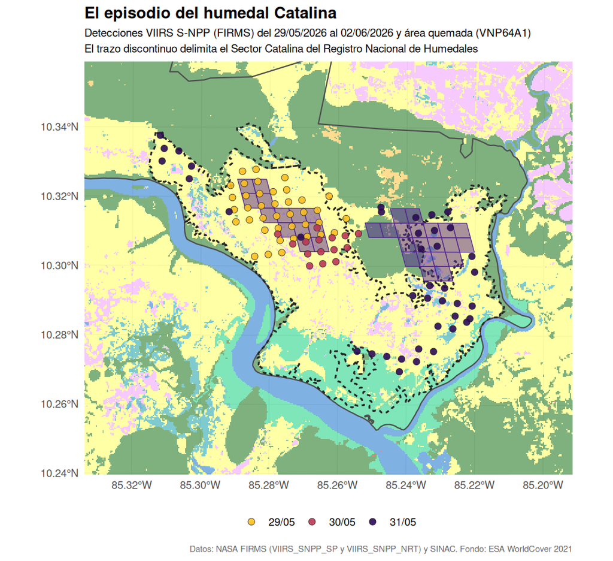

**Dónde ardió.** El **97,9 %** de las detecciones tiene como polígono dominante el *Sector Catalina* del Registro Nacional de Humedales, el mismo sector estuarino de 4 453 ha que la sección anterior identifica como el gran polígono del registro dentro del parque. Y el **93,6 %** cae en footprints donde WorldCover ve *pastizal*. Es la demostración más nítida del hallazgo de la sección anterior: el “pastizal” que arde en Palo Verde no es potrero sino marisma, y en este caso sabemos por la fuente periodística que lo que ardió fue un typhal sobre agua.

**Lo que el área quemada no vio.** Aquí está el resultado que más obliga a matizar el resto del reporte. Para mayo y junio de 2026, VNP64A1 marca **706 hectáreas** quemadas dentro del parque, frente a las 4 000 reportadas oficialmente: el producto satelital ve **5,7 veces menos superficie** que la contabilizada en tierra. El mapa de arriba lo muestra sin necesidad de cifras: las detecciones de fuego activo cubren buena parte del sector, mientras que los píxeles de área quemada forman unas pocas manchas sueltas.

La explicación está en cómo funciona el producto. VNP64A1 declara quemado un píxel de 500 m cuando detecta un **cambio persistente de reflectancia**, y una quema de *Typha* sobre lámina de agua no lo produce: la vegetación emergente desaparece, el agua vuelve a dominar la señal y a las pocas semanas la superficie se parece a lo que era antes. A eso se suma que el píxel de 500 m no resuelve las cicatrices delgadas e interrumpidas que deja un fuego que avanza entre canales. No es un defecto de este episodio: es el comportamiento esperable del algoritmo en humedales, y advierte contra leer las hectáreas de la tabla anual como una medida de la superficie realmente afectada. **Sirven para comparar años entre sí; no para responder cuántas hectáreas se quemaron.**

## ¿El fuego bordea el bosque o lo rodea?

El reporte MODIS concluye que el fuego no bordea el bosque sino que lo rodea: ocurre en las áreas abiertas y, como el bosque forma un bloque compacto, lo abierto es justamente lo que lo circunda. Repetir el análisis con VIIRS es una prueba exigente, porque el argumento central de aquel reporte era que parte de las detecciones atribuidas al interior del bosque eran un artefacto del footprint de ~1 km.

El primer indicio está en la composición: el parque es **54,0 %** bosque y **36,0 %** pastizal según WorldCover, pero solo el **17,6 %** de las detecciones tiene bosque como clase dominante de su footprint, frente al **79,7 %** con pastizal. El área quemada apunta en la misma dirección: el **18,3 %** de las hectáreas quemadas cae en píxeles dominados por bosque, contra el **70,7 %** en pastizal.

Para separar el “efecto de borde” de la ilusión geométrica se compara cada detección contra un modelo nulo: **3000** puntos aleatorios dentro del parque, es decir, la hipótesis de que el fuego se distribuye como el paisaje disponible. De cada punto se calcula la fracción de bosque en **500 m** a la redonda, que tiende a 1 en el interior del bosque y a 0 en terreno abierto; los valores intermedios son justamente los bordes.

| Situación paisajística | % de las detecciones | % del área quemada | % esperado por azar |
| --- | --- | --- | --- |
| Abierto (&lt;20 % de bosque alrededor) | 67.22972972972973 | 61.59685854621761 | 33.83333333333334 |
| Borde (20–80 %) | 27.36486486486486 | 32.69970026093951 | 28.2 |
| Interior de bosque (&gt;80 %) | 5.405405405405405 | 5.703441192842876 | 37.96666666666667 |

La tabla contrasta tres repartos: el de las detecciones, el del área quemada —medida sobre los centroides de los **263** píxeles de VNP64A1 y ponderada por su superficie— y el esperado por azar.

### VIIRS confirma que el “fuego de interior” era un artefacto del píxel

Aquí aparece el resultado más interesante de repetir el análisis con otro sensor. El reporte MODIS encuentra un **16,4 %** de detecciones en interior de bosque y argumenta que buena parte de esa cifra es un artefacto: un footprint de más de 1 km² centrado en la marisma invade el bosque contiguo y la detección termina clasificada como interior forestal. Si esa explicación es correcta, un sensor con footprints mucho menores debería registrar bastante menos fuego “de interior”.

Es exactamente lo que ocurre: con VIIRS el interior de bosque baja al **5,4 %**, menos de la mitad que con MODIS, pese a analizar el mismo parque, el mismo modelo nulo y un período que se solapa por completo. La predicción que el reporte MODIS dejó planteada se cumple con un instrumento independiente.

La conclusión es la misma que con MODIS y ahora descansa en dos sensores y dos productos de área quemada independientes: **el fuego no bordea el bosque, lo rodea**. El patrón es coherente con quemas en la marisma y el pastizal estacionalmente secos, que se detienen al llegar al bosque, más que con incendios de dosel. Para el manejo del parque esto ubica el riesgo en la interfaz entre la marisma y el bosque, aunque el fuego mismo no muestre preferencia por esa interfaz.

**Limitación**: el modelo nulo supone que cualquier punto del parque tiene la misma probabilidad de arder, lo que ignora factores como la accesibilidad o la cercanía a caminos y linderos. Descarta la explicación geométrica del patrón, pero no identifica la causa de las igniciones.

## Fuentes de datos

- **NASA FIRMS** — Fire Information for Resource Management System, producto VIIRS_SNPP_SP (VIIRS 375 m, Suomi-NPP, procesamiento estándar). https://firms.modaps.eosdis.nasa.gov/. Cita sugerida: Schroeder, W., y Giglio, L. (2018). *VIIRS/NPP Thermal Anomalies/Fire 6-Min L2 Swath 375m*, DOI: 10.5067/VIIRS/VNP14IMG.002.
- **NASA LP DAAC** — producto de área quemada VNP64A1 v002 (VIIRS/NPP, mensual, 500 m), descubierto vía el API CMR de Earthdata. Giglio, L., y Justice, C. (2021). *VNP64A1 VIIRS/NPP Burned Area Monthly L4 Global 500m SIN Grid V002*, DOI: 10.5067/VIIRS/VNP64A1.002.
- **SINAC** — Sistema Nacional de Áreas de Conservación de Costa Rica. Capas de áreas silvestres protegidas (capa oficial 1:5000, publicada en 2019), Registro Nacional de Humedales (actualización 2016–2018) y Cobertura Forestal 2023, descargadas de su servicio WFS. https://geos1pne.sirefor.go.cr/wfs.
- **ESA WorldCover** — mapa global de cobertura de la tierra 2021 a 10 m, v200. https://esa-worldcover.org/. Zanaga, D., et al. (2022). *ESA WorldCover 10 m 2021 v200*, DOI: 10.5281/zenodo.7254221.

Los reportes análogos: MODIS (desde 2001), VIIRS en NOAA-20 (desde 2018) y VIIRS en NOAA-21 (desde 2024).

El código de este análisis está disponible en https://github.com/incendios-forestales/anomalias-termicas-paloverde.